# Workflow

5 January 2022

# 1 Introduction

This is a description of the workflow for *cytofQC*, which applies QC labels to each observation in a CyTOF dataset. The vignette shows how to use the general function to obtain labels and probabilities for all of the observations in a CyTOF data set. We then demonstrate the inner workings of the function to illustrate how it works for each observation type and show how to use the individual modeling functions that make up . we then end with a demonstration of how the labeled data cluster using UMAP.

```r
library(cytofQC)
library(ggplot2)
```

# 2 Read in data and create initial dataset

The function read in the data and formats a that contains all of the QC variables. The variables are renamed so that their names can be easily accessed by downstream functions. The help file specifies how to do this. The Gaussian parameters and event length are transformed with the function. The output is a .

```r
f <- "../../data/FlowRepository_FR-FCM-Z29V_files/REP_1_deid.fcs"
tech <- dataPrep(f)
head(tech)
```

```
#>        Time     Bead1      Bead2     Bead3     Bead4     DNA1     DNA2
#> [1,]  5.977 0.5353587 0.00000000 0.0000000 0.0000000 6.283590 6.870065
#> [2,]  6.797 0.4405158 0.03591994 0.1970803 0.3929467 7.374675 7.993201
#> [3,]  9.831 0.7219333 0.25544609 0.2756382 0.0000000 6.347878 7.036312
#> [4,] 11.198 0.4397861 0.00000000 0.1056234 0.0000000 7.257359 7.790603
#> [5,] 15.573 1.4154224 0.00000000 0.0000000 0.0000000 6.446611 6.999243
#> [6,] 16.289 0.3427553 0.00000000 0.0000000 0.6263391 6.570251 7.116003
#>      Viability Event_length   Center   Offset    Width Residual
#> [1,] 0.3147367     3.091042 6.866417 4.644997 4.175033 4.589000
#> [2,] 0.6138486     3.496508 7.351517 4.295338 4.211831 5.018517
#> [3,] 0.4113440     3.496508 7.308466 4.665908 4.591649 4.480332
#> [4,] 0.0495718     3.688879 7.521476 4.545558 4.660633 4.398663
#> [5,] 0.0000000     3.526361 7.241088 4.498943 4.458223 4.672277
#> [6,] 0.0000000     3.258097 6.914749 4.390441 4.057871 4.260523
```

# 3 Use labelQC to obtain labels for each obsevation

The integral function of cytofQC is . A obtained from can be passed to with no other arguments and it will return a that contains all of the labels and the probability that each observation belongs to each of the specified labels. The data we are using for this vignette has only live cells so we call in a way that omits the labeling of the live/dead cells. The following call will label the cells using a support vector machine and mutual nearest neighbors.

```r
labels <- labelQC(tech, types = c("bead", "doublet", "debris"))
head(labels)
```

```
#>     Time label         bead      doublet       debris dead
#> 1  5.977  cell 7.005861e-05 1.000000e-07 2.808661e-04   NA
#> 2  6.797  cell 4.744935e-05 2.625128e-03 1.000000e-07   NA
#> 3  9.831  cell 3.843812e-05 1.000000e-07 1.000000e-07   NA
#> 4 11.198  cell 3.462181e-05 1.808089e-05 1.000000e-07   NA
#> 5 15.573  cell 3.494460e-05 2.562091e-07 1.000000e-07   NA
#> 6 16.289  cell 1.021096e-04 1.664550e-07 3.703289e-06   NA
```

```r
table(labels$label)
```

```
#>
#>    bead    cell  debris doublet GDPzero
#>    5424  234158   23870   26022   10526
```

# 4 How does labelQC work?

The following workflow demonstrates what is happening in the function. The user can use any of these functions to customize a labeling algorithm. We start with creating the basic labeling . The function creates a that contains the labels and information about the labels. It is built using the dataset. The first variable is the label and each observation is assigned a label of either *cell* or *GDPzero*. The *GDPzero* label is assigned to any variable that has a 0 for any of the GDP variables. The has variables for beads, doublets, debris, and viability. The values for those variables are initially set to *NA*. The purpose of this dataset is to iteratively change the label for the observations and assign probabilities to each observation in regard its status as a bead, doublet, debris, or live/dead cell.

```r
labels <- qcDataFrame(tech)
head(labels)
```

```
#>     Time label bead doublet debris dead
#> 1  5.977  cell   NA      NA     NA   NA
#> 2  6.797  cell   NA      NA     NA   NA
#> 3  9.831  cell   NA      NA     NA   NA
#> 4 11.198  cell   NA      NA     NA   NA
#> 5 15.573  cell   NA      NA     NA   NA
#> 6 16.289  cell   NA      NA     NA   NA
```

```r
table(labels$label)
```

```
#>
#>    cell GDPzero
#>  289474   10526
```

# 5 Nearest neighbors

The next piece in the process is finding the nearest neighbors for each of the observations. There are currently two choices: k-means nearest neighbors and mutual nearest neighbors. This piece only needs to be done once.

```r
# K-means nearest neighbors
knn <- NN(tech, n = 10, type = "knn")
head(knn)
dim(knn)
```

```r
# Mutual nearest neighbors
mnn <- NN(tech, n = 20, type = "mnn")
head(mnn)
```

```
#>        Time
#> [1,]  5.977  24337  81142  37757 105856 100021 217892 285616 194276  60478
#> [2,]  6.797 186500     NA     NA  22350     NA     NA     NA     NA     NA
#> [3,]  9.831   9361  66258  85518     NA     NA     NA  44419     NA     NA
#> [4,] 11.198 115833 166796  21728 109123  21341 246277 193396     NA 242966
#> [5,] 15.573 279360 105276 247357 192732 241703     NA     NA     NA     NA
#> [6,] 16.289 234728    103     NA 170181 120088 174874     NA     NA     NA
#>
#> [1,] 108564     NA 273047  20255 176835  61000  72909     NA 277133  91416 NA
#> [2,]     NA     NA     NA     NA     NA     NA     NA     NA     NA     NA NA
#> [3,]     NA 144602     NA     NA     NA     NA     NA 114658     NA     NA NA
#> [4,]     NA     NA 159443 119035   9465     NA 192670     NA  64206 240477 NA
#> [5,]     NA     NA     NA     NA     NA     NA     NA     NA     NA     NA NA
#> [6,]  13391     NA     NA 199561 230667 221096  99824     NA  32798     NA NA
```

```r
dim(mnn)
```

```
#> [1] 300000     21
```

# 6 Beads

## 6.1 Initial bead labeling

```r
beads <- initialBead(tech, labels)
head(beads)
```

```
#>     Time beadScore  init
#> 1  5.977 0.5353587 FALSE
#> 2  6.797 1.0664627 FALSE
#> 3  9.831 1.2530176 FALSE
#> 4 11.198 0.5454095 FALSE
#> 5 15.573 1.4154224 FALSE
#> 6 16.289 0.9690944 FALSE
```

```r
sum(beads$init)
```

```
#> [1] 5421
```

The function can be used to visualize the data with regard to a grouping variable. This allows us to see what is classified as beads in the original bead data. TRUE indicates observations that are initially characterized as beads.

```r
beadPlots <- NULL
for (i in 1:4) {
  beadPlots[[i]] <- cytofHist(x = tech[, i + 1], group = beads$init,
                             title = paste("Bead channel", i))
}
```

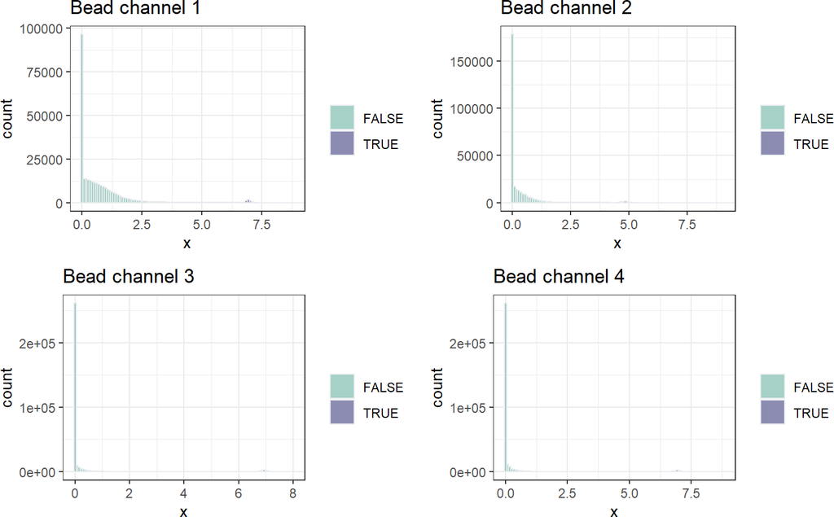

```r
ggpubr::ggarrange(plotlist = beadPlots, ncol = 2, nrow = 2)
```

The zeros make it difficult to see the trends, so here are the plots without the zeros. The density option can be used to emphasize the smaller group.

```r
beadPlots2 <- NULL
for (i in 1:4) {
  tmp <- data.frame(bead = tech[, i + 1], group = beads$init)
  tmp <- tmp[tmp$bead > 0, ]
  beadPlots2[[i]] <- cytofHist(x = tmp$bead, group = tmp$group,
                               type = "density",
                               title = paste("Bead channel", i))
}
```

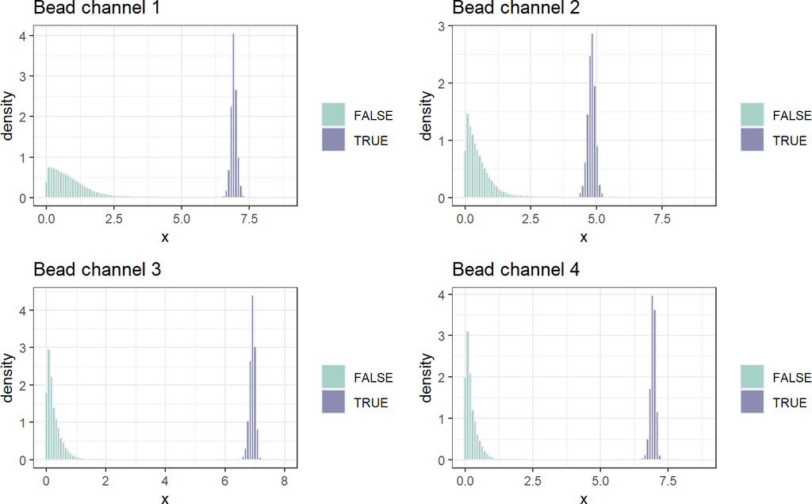

```r
ggpubr::ggarrange(plotlist = beadPlots2, ncol = 2, nrow = 2)
```

## 6.2 Identify Matches

The user can change how strict the threshold for being a match is by adjusting the *threshold* argument. The default is that all of the neighbors must be a match for the observation to be given a value of TRUE for the *match* variable.

```r
sure <- surematch(mnn, beads$init, threshold = 0)
head(sure)
```

```
#>     Time   nn1   nn2   nn3   nn4   nn5   nn6   nn7   nn8   nn9  nn10  nn11
#> 1  5.977 FALSE FALSE FALSE FALSE FALSE FALSE FALSE FALSE FALSE FALSE FALSE
#> 2  6.797 FALSE FALSE FALSE FALSE FALSE FALSE FALSE FALSE FALSE FALSE FALSE
#> 3  9.831 FALSE FALSE FALSE FALSE FALSE FALSE FALSE FALSE FALSE FALSE FALSE
#> 4 11.198 FALSE FALSE FALSE FALSE FALSE FALSE FALSE FALSE FALSE FALSE FALSE
#> 5 15.573 FALSE FALSE FALSE FALSE FALSE FALSE FALSE FALSE FALSE FALSE FALSE
#> 6 16.289 FALSE FALSE FALSE FALSE FALSE FALSE FALSE FALSE FALSE FALSE FALSE
#>    nn12  nn13  nn14  nn15  nn16  nn17  nn18  nn19  nn20 match
#> 1 FALSE FALSE FALSE FALSE FALSE FALSE FALSE FALSE FALSE  TRUE
#> 2 FALSE FALSE FALSE FALSE FALSE FALSE FALSE FALSE FALSE  TRUE
#> 3 FALSE FALSE FALSE FALSE FALSE FALSE FALSE FALSE FALSE  TRUE
#> 4 FALSE FALSE FALSE FALSE FALSE FALSE FALSE FALSE FALSE  TRUE
#> 5 FALSE FALSE FALSE FALSE FALSE FALSE FALSE FALSE FALSE  TRUE
#> 6 FALSE FALSE FALSE FALSE FALSE FALSE FALSE FALSE FALSE  TRUE
```

```r
sum(sure$Mismatch)
```

```
#> [1] 0
```

## 6.3 Create a subset of data to train a model

We plan to create a model using a smaller set of data. This next piece selects a subset of data points to build the model. Only the matches selected by the previous piece are considered to be in this subset. If no points are designated as sure matches, the entire set of unclassified data points (those that still have a *cell* label) is sampled. The data are sampled at random, but weighted to ensure we have a fairly balanced dataset to build the labeling model with. The function returns a set of indices that identifies the points in the dataset that will be used to compute the labeling model.

```r
ind <- modelData(labels, subset = sure$match, init = beads$init, n = 4000)
length(ind)
```

```
#> [1] 4000
```

```r
head(ind)
```

```
#> [1] 246238 247515 288826 227492  79942 121066
```

The following histogram shows where the selected points are relative to the rest of the points for each of the bead channels. Note that TRUE designates the points that were selected to train the model.

```r
index <- rep(FALSE, nrow(tech))
index[ind] <- TRUE
beadPlots3 <- NULL
for (i in 1:4) {
  beadPlots3[[i]] <- cytofHist(x = tech[, i + 1], group = index,
                               type = "density",
                               title = paste("Bead channel", i))
}
```

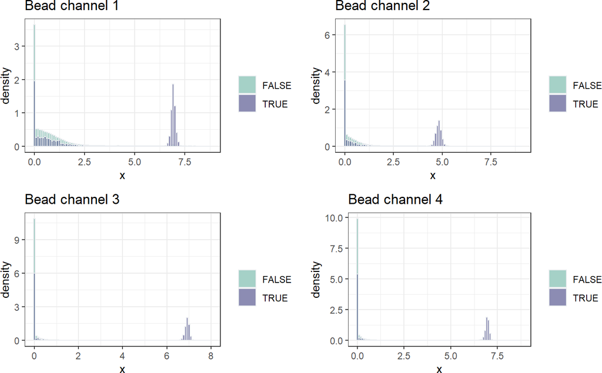

```r
ggpubr::ggarrange(plotlist = beadPlots3, ncol = 2, nrow = 2)
```

## 6.4 Final classification of beads

There are currently three models that can be used to classify the beads: support vector machines (SVMs), random forests, and gradient boosting machines (GBMs). The method below uses random forests, but the process is identical for SVMs and GBMs. The functions for SVMs and GBMs are and . The labeling functions take the same input and produce identical output. The output is a that is identical to the but with the beads labeled as beads and the predicted probability of being a bead assigned to each observation in the *bead* variable. This is the *labels* that should be used for the next step because the *bead* label is needed for all other QC labels.

```r
rf.labs <- rfLabel(tech, labels, type = "bead", init = beads$init, index = ind)
head(rf.labs)
```

```
#>     Time label bead doublet debris dead
#> 1  5.977  cell    0      NA     NA   NA
#> 2  6.797  cell    0      NA     NA   NA
#> 3  9.831  cell    0      NA     NA   NA
#> 4 11.198  cell    0      NA     NA   NA
#> 5 15.573  cell    0      NA     NA   NA
#> 6 16.289  cell    0      NA     NA   NA
```

```r
table(rf.labs$label)
```

```
#>
#>    bead    cell GDPzero
#>    5422  284052   10526
```

The following plots show a histogram of the bead measurement with the groups for each cell type shown in the plot. Note that the observations with a bead measurement of zero have been omitted from the plot because they dominate the histogram and make it difficult to see the three groups.

```r
beadPlots <- NULL
for (i in 1:4) {
  tmp <- data.frame(bead = tech[, i + 1], group = rf.labs$label)
  tmp <- tmp[tmp$bead > 0, ]
  beadPlots[[i]] <- cytofHist(tmp$bead, group = tmp$group, type = "count",
                              title = paste("Bead channel", i))
}
```

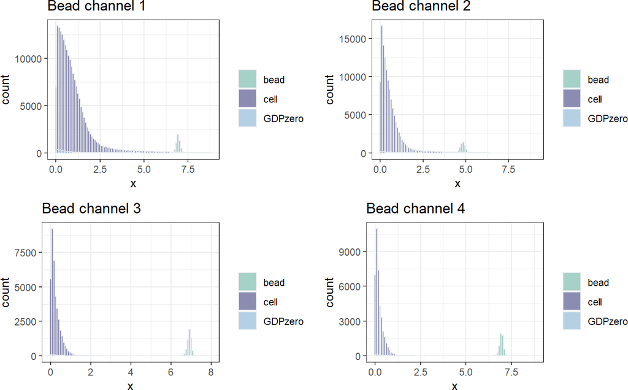

```r
ggpubr::ggarrange(plotlist = beadPlots, ncol = 2, nrow = 2)
```

# 7 Doublets

This section shows how to label the doublets. It has the exact same structure as the beads. Note that the updated label should be used because the bead labels are needed for each of the steps.

## 7.1 Initial doublet labeling

The doublets are difficult to classify and we compute a doublet score to classify them. The method used to compute the doublet score is defined in the help file for the function. There are currently three options for classifying the doublet. They are selected using the score argument and they are documented in the help file for . The function returns the doublet score, the group it was assigned to, and the initial doublet classification in the *init* variable.

```r
doublets <- initialDoublet(tech, rf.labs, score = 1)
head(doublets)
```

```
#>     Time doubletScore doubletGroup  init
#> 1  5.977  -0.86204950            2 FALSE
#> 2  6.797   2.37259568            2 FALSE
#> 3  9.831  -0.07752068            2 FALSE
#> 4 11.198   1.51575828            2 FALSE
#> 5 15.573   0.47690204            2 FALSE
#> 6 16.289  -0.07659512            2 FALSE
```

This histogram shows the initical classification of the doublet scores for the unclassified points (all of those not labeled *GDPzero* or *bead*). The scores for the classified points can be seen on the histogram by selection .

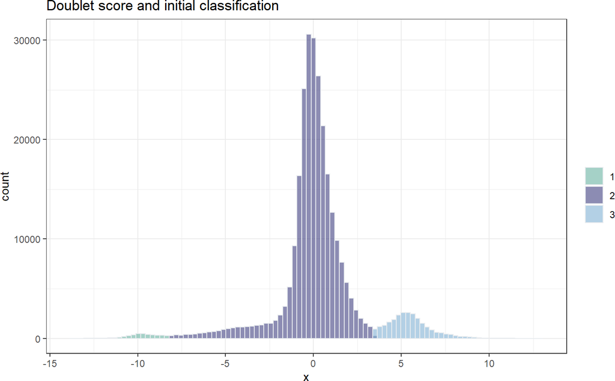

```r
cytofHist(doublets$doubletScore, doublets$doubletGroup, na.rm = TRUE,
          title = "Doublet score and initial classification")
```

## 7.2 Find matches

As with the beads, the next step is to identify the observations that are similar to each other in regard to the doublet score. The process is identical to the one used to assign the beads.

```r
sureDoublet <- surematch(mnn, doublets$init, threshold = 0)
head(sureDoublet)
```

```
#>     Time   nn1   nn2   nn3   nn4   nn5   nn6   nn7   nn8   nn9  nn10  nn11
#> 1  5.977 FALSE FALSE FALSE FALSE FALSE FALSE FALSE FALSE FALSE FALSE FALSE
#> 2  6.797 FALSE FALSE FALSE FALSE FALSE FALSE FALSE FALSE FALSE FALSE FALSE
#> 3  9.831 FALSE FALSE FALSE FALSE FALSE FALSE FALSE FALSE FALSE FALSE FALSE
#> 4 11.198 FALSE FALSE FALSE FALSE FALSE FALSE FALSE FALSE FALSE FALSE FALSE
#> 5 15.573 FALSE FALSE FALSE FALSE FALSE FALSE FALSE FALSE FALSE FALSE FALSE
#> 6 16.289 FALSE FALSE FALSE FALSE FALSE FALSE FALSE FALSE FALSE FALSE FALSE
#>    nn12  nn13  nn14  nn15  nn16  nn17  nn18  nn19  nn20 match
#> 1 FALSE FALSE FALSE FALSE FALSE FALSE FALSE FALSE FALSE  TRUE
#> 2 FALSE FALSE FALSE FALSE FALSE FALSE FALSE FALSE FALSE  TRUE
#> 3 FALSE FALSE FALSE FALSE FALSE FALSE FALSE FALSE FALSE  TRUE
#> 4 FALSE FALSE FALSE FALSE FALSE FALSE FALSE FALSE FALSE  TRUE
#> 5 FALSE FALSE FALSE FALSE FALSE FALSE FALSE FALSE FALSE  TRUE
#> 6 FALSE FALSE FALSE FALSE FALSE FALSE FALSE FALSE FALSE  TRUE
```

```r
sum(sureDoublet$match)
```

```
#> [1] 293551
```

The hisograms below show where the matched points are in relation to the rest of the points. This lets us see that the matched doublets are not too near the boundary.

```r
mmPlots <- NULL
mmPlots[[1]] <- cytofHist(doublets$doubletScore, sureDoublet$match, type = "count",
          title = "Matched doublets")
mmPlots[[2]] <- cytofHist(doublets$doubletScore, sureDoublet$match, type = "density",
          title = "Matched doublets")
```

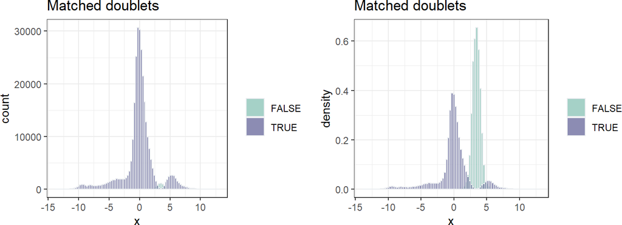

```r
ggpubr::ggarrange(plotlist = mmPlots, ncol = 2, nrow = 1)
```

## 7.3 Create a subset of data to train a doublet model

This code chunk shows how to select a random set of doublets and non-doublets to use to train a model.

```r
d.rf.index <- modelData(rf.labs, subset = sureDoublet$match, init = doublets$init, n = 4000)
```

The following histogram shows where the selected points are relative to the rest of the doublet scores.

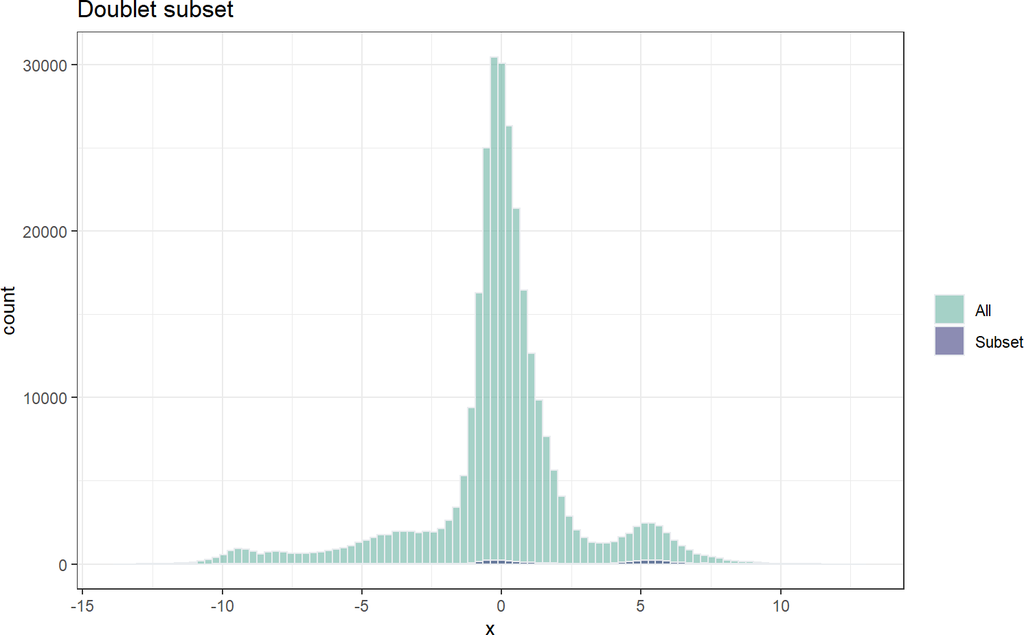

```r
index <- rep("All", nrow(tech))
index[d.rf.index] <- "Subset"
cytofHist(x = doublets$doubletScore, group = index, type = "count",
          title = "Doublet subset")
```

## 7.4 Final classification of doublets

This shows the classification of doublets with random forests. Note that the label dataset from the last round of classifying is used as an input and the results are assigned to the same object.

```r
rf.labs <- rfLabel(tech, rf.labs, type = "doublet", init = doublets$init, index = d.rf.index)
head(rf.labs)
```

```
#>     Time label bead doublet debris dead
#> 1  5.977  cell    0   0.000     NA   NA
#> 2  6.797  cell    0   0.090     NA   NA
#> 3  9.831  cell    0   0.000     NA   NA
#> 4 11.198  cell    0   0.014     NA   NA
#> 5 15.573  cell    0   0.000     NA   NA
#> 6 16.289  cell    0   0.000     NA   NA
```

```r
table(rf.labs$label)
```

```
#>
#>    bead    cell doublet GDPzero
#>    5422  257561   26491   10526
```

The following histogram shows doublet scores for the different groups that have been classified up to this point.

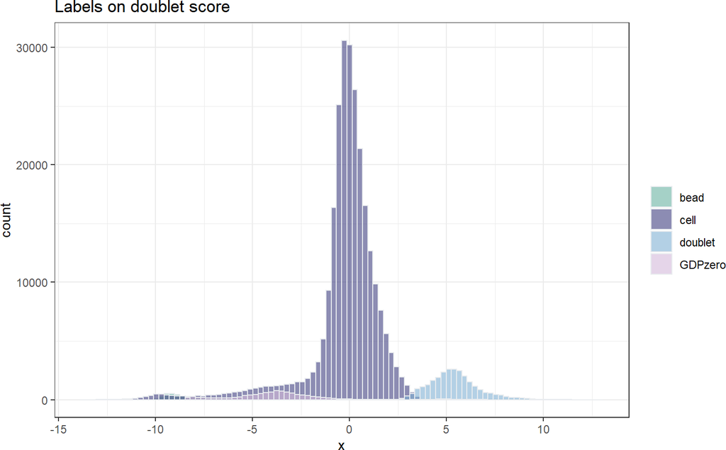

```r
cytofHist(doublets$doubletScore, rf.labs$label, type = "count",
          title = "Labels on doublet score")
```

# 8 Debris

This section shows how to label the debris. It has the exact same structure as the beads and doublets. Note that the updated label should be used because the previous labels are needed for this step.

## 8.1 Initial debris labeling

We compute a debris score to do a prelimnary classification of debris and non-debris. There are currently three options for classifying debris. They are selected using the score argument and they are documented in the help file for . The function returns the debris score, the group it was assigned to, and the initial debris classification in the *init* variable.

```r
debris <- initialDebris(tech, rf.labs, score = 1)
head(debris)
```

```
#>     Time debrisScore debrisGroup  init
#> 1  5.977   0.6532046           1 FALSE
#> 2  6.797  -1.7599665           1 FALSE
#> 3  9.831  -1.1297679           1 FALSE
#> 4 11.198  -2.9762232           1 FALSE
#> 5 15.573  -0.9401198           1 FALSE
#> 6 16.289  -0.3957497           1 FALSE
```

This histogram shows a classification of the debris scores for the unclassified points (all of those not labeled as *bead*, *doublet*, or *GDPzero*). The scores for the classified points can be seen on the histogram by selecting . A label of 1 indicates a low debris score, or less likely to be debris, and a label of 2 indicates it is likely debris.

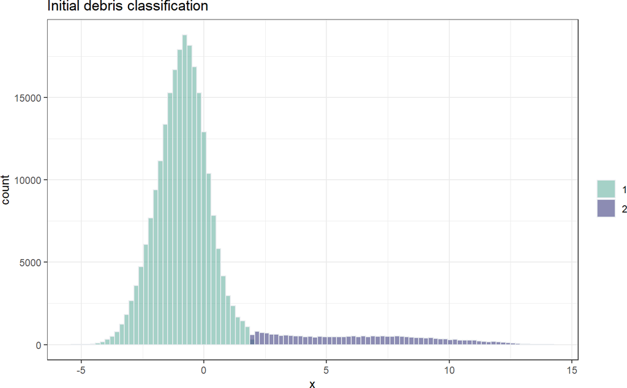

```r
cytofHist(debris$debrisScore, debris$debrisGroup, na.rm = TRUE,
          title = "Initial debris classification")
```

## 8.2 Find mismatches

This next part identifies the observations that are mismatched from its neighbors in regard to debris assignment using the nearest neighbors matrix.

```r
debm <- surematch(mnn, debris$init, threshold = 0)
head(debm)
```

```
#>     Time   nn1   nn2   nn3   nn4   nn5   nn6   nn7   nn8   nn9  nn10  nn11
#> 1  5.977 FALSE FALSE FALSE FALSE FALSE FALSE FALSE FALSE FALSE FALSE FALSE
#> 2  6.797 FALSE FALSE FALSE FALSE FALSE FALSE FALSE FALSE FALSE FALSE FALSE
#> 3  9.831 FALSE FALSE FALSE FALSE FALSE FALSE FALSE FALSE FALSE FALSE FALSE
#> 4 11.198 FALSE FALSE FALSE FALSE FALSE FALSE FALSE FALSE FALSE FALSE FALSE
#> 5 15.573 FALSE FALSE FALSE FALSE FALSE FALSE FALSE FALSE FALSE FALSE FALSE
#> 6 16.289 FALSE FALSE FALSE FALSE FALSE FALSE FALSE FALSE FALSE FALSE FALSE
#>    nn12  nn13  nn14  nn15  nn16  nn17  nn18  nn19  nn20 match
#> 1 FALSE FALSE FALSE FALSE FALSE FALSE FALSE FALSE FALSE  TRUE
#> 2 FALSE FALSE FALSE FALSE FALSE FALSE FALSE FALSE FALSE  TRUE
#> 3 FALSE FALSE FALSE FALSE FALSE FALSE FALSE FALSE FALSE  TRUE
#> 4 FALSE FALSE FALSE FALSE FALSE FALSE FALSE FALSE FALSE  TRUE
#> 5 FALSE FALSE FALSE FALSE FALSE FALSE FALSE FALSE FALSE  TRUE
#> 6 FALSE FALSE FALSE FALSE FALSE FALSE FALSE FALSE FALSE  TRUE
```

```r
sum(debm$Mismatch)
```

```
#> [1] 0
```

The following histogram shows the debris scores for the observations that are candidates for model training. Note that the matched observations are away from the boundary between the two groups.

```r
mmPlots <- NULL
mmPlots[[1]] <- cytofHist(debris$debrisScore, debm$match, type = "count",
          title = "Mismatched debris")
mmPlots[[2]] <- cytofHist(debris$debrisScore, debm$match, type = "density",
          title = "Mismatched debris")
```

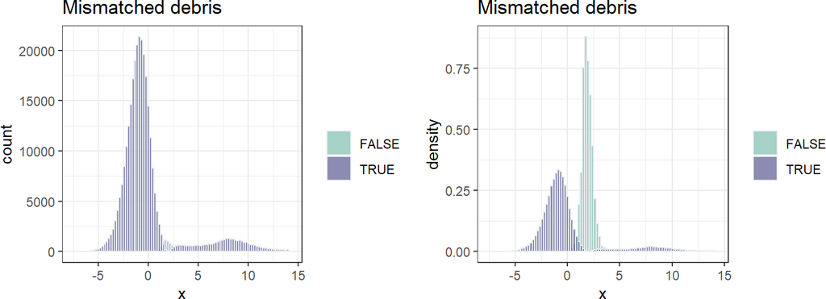

```r
ggpubr::ggarrange(plotlist = mmPlots, ncol = 2, nrow = 1)
```

## 8.3 Create a subset of data to train a debris model

The debris have enough matches to draw from to select a dataset from the matches. The following code chunk selects a training dataset for the model.

```r
de.rf.index <- modelData(rf.labs, subset = debm$match, init = debris$init, n = 4000)
```

The following histogram shows where the selected points are relative to the rest of the debris scores. Note that the ‘density’ option is used so that the groups can be seen. When the ‘count’ option is used it is almost impossible to see the selected points on the histogram.

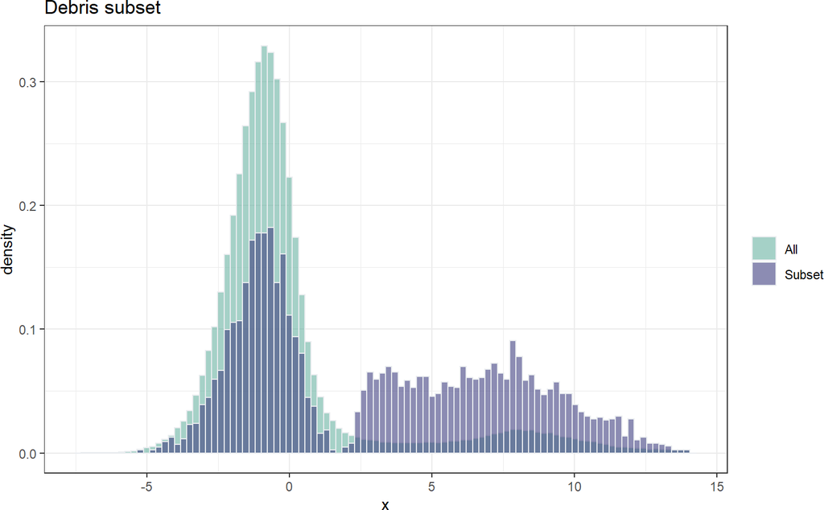

```r
index <- rep("All", nrow(tech))
index[de.rf.index] <- "Subset"
cytofHist(x = debris$debrisScore, group = index, type = "density",
          title = "Debris subset")
```

## 8.4 Final classification of debris

The following code show how to do the final classification of debris with random forests. Note that the label dataset from the last round of classifying is used as an input and the results are assigned to the same object.

```r
rf.labs <- rfLabel(tech, rf.labs, type = "debris", init = debris$init, index = de.rf.index)
head(rf.labs)
```

```
#>     Time label bead doublet debris dead
#> 1  5.977  cell    0   0.000  0.006   NA
#> 2  6.797  cell    0   0.090  0.000   NA
#> 3  9.831  cell    0   0.000  0.000   NA
#> 4 11.198  cell    0   0.014  0.000   NA
#> 5 15.573  cell    0   0.000  0.000   NA
#> 6 16.289  cell    0   0.000  0.002   NA
```

```r
table(rf.labs$label)
```

```
#>
#>    bead    cell  debris doublet GDPzero
#>    5422  231701   25860   26491   10526
```

This histogram shows the debris score for the observations that have been labeled up to this point. You can see that the observations that are labeled *debris* and *GDPzero*.

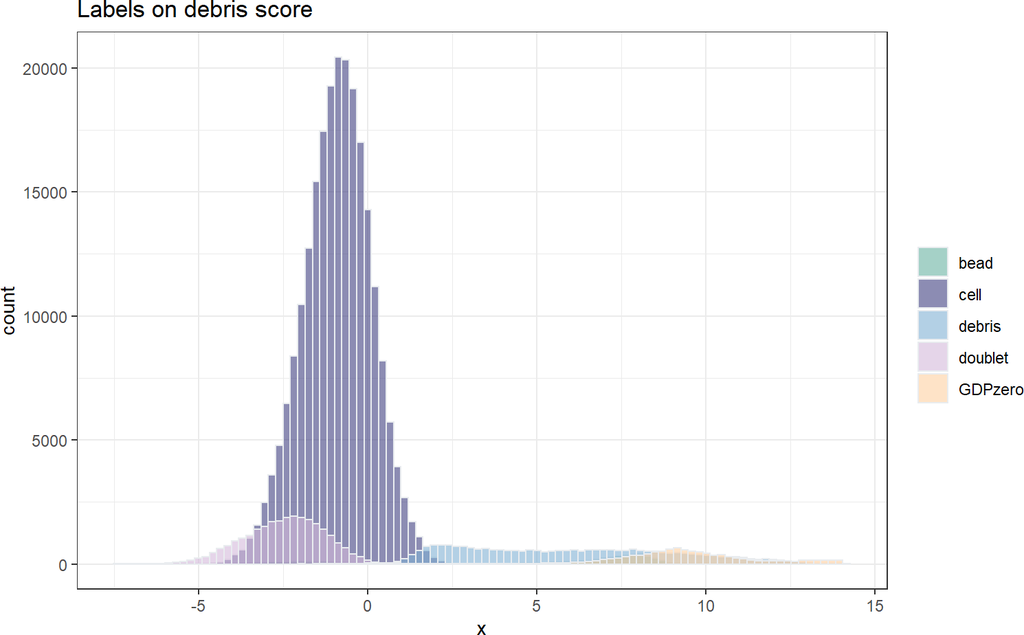

```r
cytofHist(debris$debrisScore, rf.labs$label, type = "count",
          title = "Labels on debris score")
```

# 9 Final summary

The following shows the final labels on the different metrics used to classify the observations.

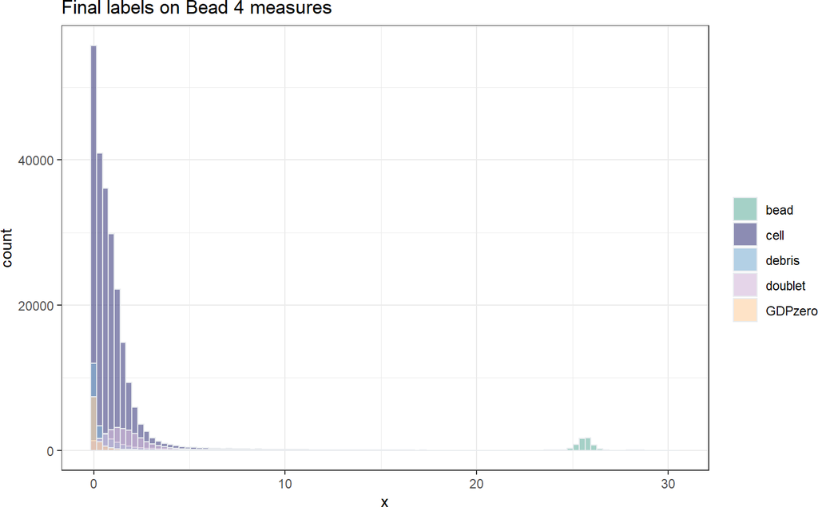

```r
cytofHist(rowSums(tech[, c("Bead1", "Bead2", "Bead3", "Bead4")]), rf.labs$label,
          title = "Final labels on Bead 4 measures")
```

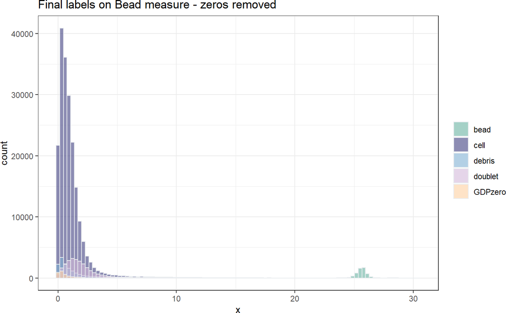

```r
tmp <- data.frame(bead = rowSums(tech[, c("Bead1", "Bead2", "Bead3", "Bead4")]),
                  group = rf.labs$label)
tmp <- tmp[tmp$bead > 0, ]
cytofHist(tmp$bead, tmp$group, title = "Final labels on Bead measure - zeros removed")
```

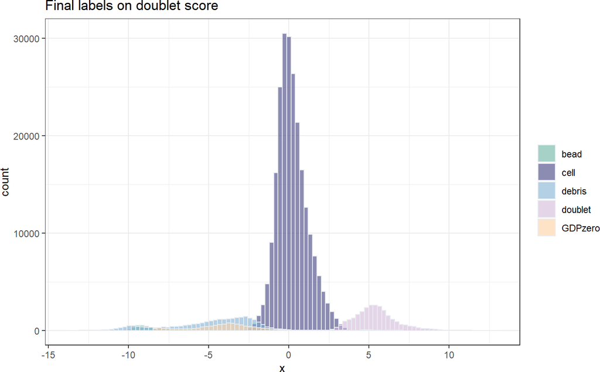

```r
cytofHist(doublets$doubletScore, rf.labs$label, title = "Final labels on doublet score")
```

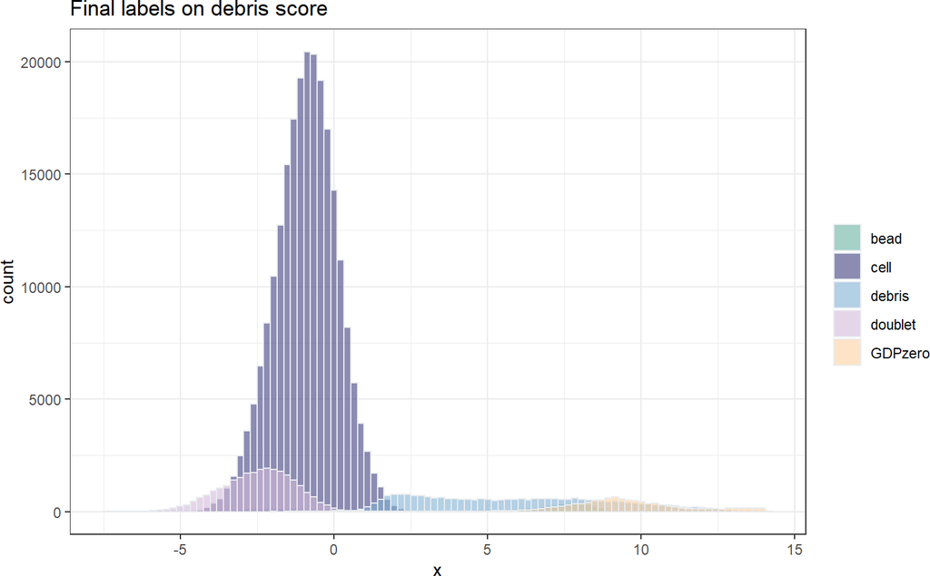

```r
cytofHist(debris$debrisScore, rf.labs$label, title = "Final labels on debris score")
```

This is a umap of the different labels. the umap was created using the standardized *tech* data.

```r
s.tech <- scale(tech[, -1])
lab.umap <- uwot::umap(s.tech, ret_model = TRUE)
lab.umapD <- data.frame(x = lab.umap$embedding[, 1], y = lab.umap$embedding[, 2])
```

```r
umapData <- data.frame(lab.umapD, labels = rf.labs$label)
umapData$bead <- ifelse(rf.labs$label == "bead", "Bead", "Not-Bead")
umapData$doublet <- ifelse(rf.labs$label == "doublet", "Doublet", "Not-Doublet")
umapData$debris <- ifelse(rf.labs$label == "debris", "Debris", "Not-Debris")
umapData$GDPzero <- ifelse(rf.labs$label == "GDPzero", "GDPzero", "Not-GDPzero")
umapData$cell <- ifelse(rf.labs$label == "cell", "Cells", "Not-Cells")

umapData$labels <- factor(umapData$labels, levels = c("cell", "GDPzero", "bead", "doublet", "debris"))
```

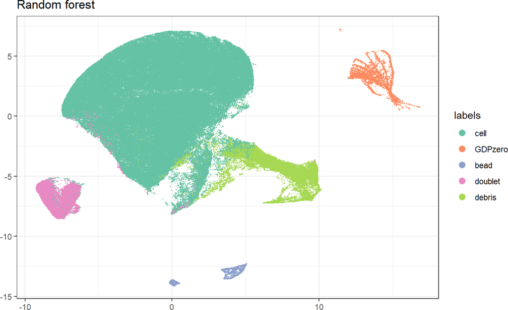

```r
require(RColorBrewer)
cols <- brewer.pal(5, "Set2")
umapG <- ggplot(umapData, aes(x = x, y = y, color = labels)) +
  geom_point(size = 0.25) +
  scale_color_manual(values = cols) +
  labs(title = "Random forest", x = "", y = "") +
  guides(colour = guide_legend(override.aes = list(size = 3))) +
  theme_bw()

umapG
```

Split out by cell type

```r
umaps <- NULL
cell_type <- levels(umapData$labels)

for (i in 1:5) {
  tmp <- data.frame(umapData[, 1:2], lab = umapData[, cell_type[i]])
  umaps[[i]] <- ggplot(tmp, aes(x = x, y = y, color = lab)) +
    geom_point(size = 0.25, show.legend = FALSE) +
    scale_color_manual("", values = c(cols[i], "gray80")) +
    labs(title = cell_type[i], x = "", y = "") +
    theme_bw()
}
```

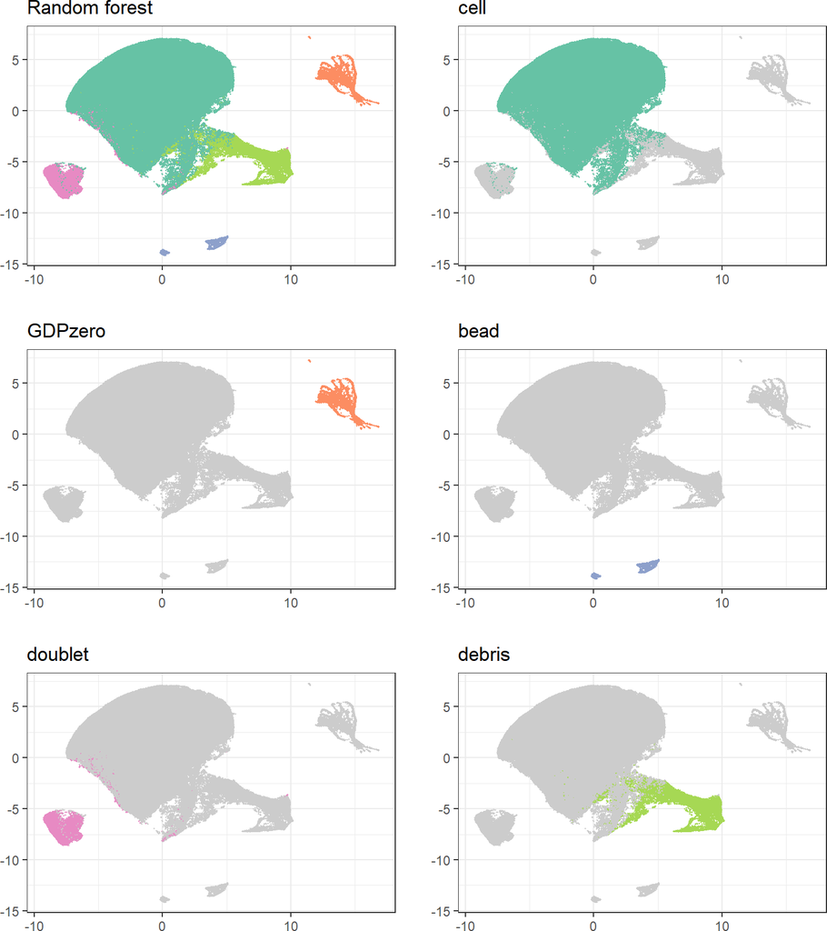

```r
library(gridExtra)
grid.arrange(umapG + guides(col = "none"), umaps[[1]], umaps[[2]],
             umaps[[3]], umaps[[4]], umaps[[5]], nrow = 3, ncol = 2)
```